# Series temporales en R

## 7.2 Correlación entre variables

Si tenemos varias variables relacionadas, una forma de ver graficamente los coeficientes de correpación entre cada par de variables es usar la función `ggpairs()` del paquete **GGally**. El resultado nos dá la matriz gráfica de autocorrepaciones entre las series.

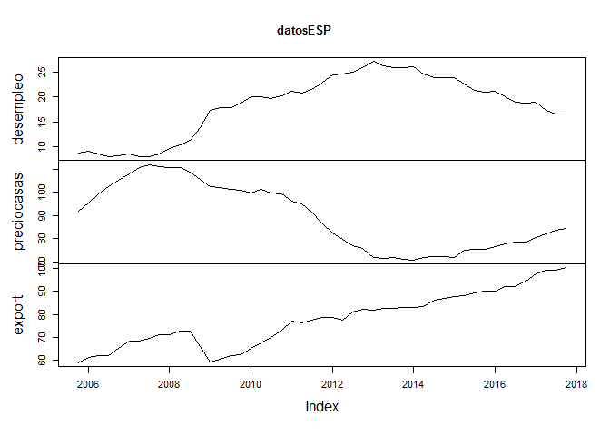

```r
    #Añadimos a la serie anterior de datosEsp las exportaciones
    expESP <- getSymbols("ESPEXPORTQDSMEI",
                       src ="FRED",
                       warning= "FALSE",
                       from ="2006-01-01", to ="2017-01-01",
                       adjust = TRUE,
                       auto.assign=FALSE)

    # añadimos la serie de exportaciones
    datosESP<- cbind(datosESP,expESP)

    # Eliminamos las filas sin ambos datos
    datosESP<-datosESP[complete.cases(datosESP),]
     colnames(datosESP)[3]<-"export"
    plot.zoo(datosESP)
```

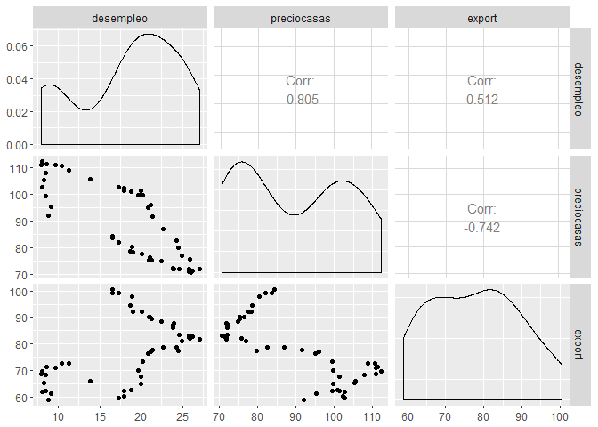

```r
    # También podemos ver la relacioó entre las variables con GGally
    datosESP %>%
        as.data.frame() %>%
        GGally::ggpairs()
```

## 7.3 Regresión múltiple

La función `tlsm()` del paquete forecast, realiza pronósticos de regresion lineal a partir de la descomposición de una serie temporal. El modelo permite especificar una formula de pronostico.

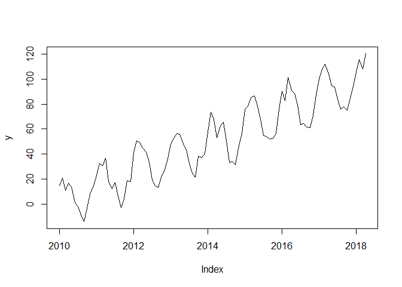

```r
    require(forecast)
    # Creamos una serie de ejemplo periodica y con tendencia
    y <- ts(rnorm(100,0,5) + 1:100 + 20*sin(2*pi*(1:100)/12), frequency=12, start = 2010)
    plot.zoo(y)
```

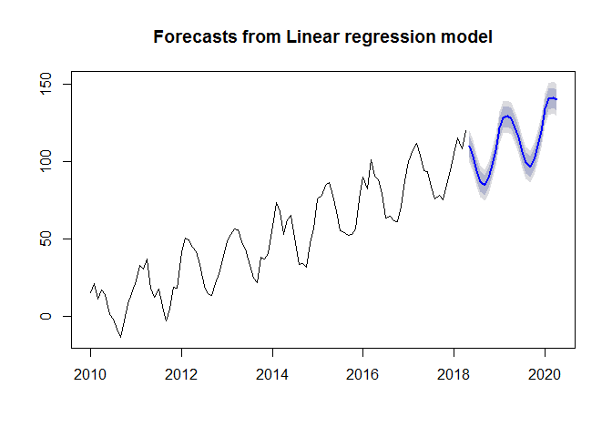

```r
    # predicción usando tendencia y estacionalidad
    fit <- tslm(y ~ trend + season)
    plot(forecast(fit, h=24))
```

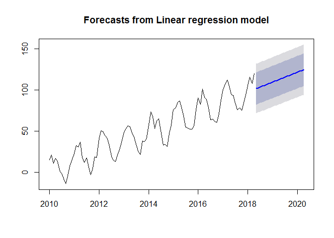

```r
    # predicción solo usando la tendencia
    fit <- tslm(y ~ trend)
    plot(forecast(fit, h=24))
```

## 7.4 Suavizamiento exponencial simple

La función `ses()` produce pronósticos de regresión obtenidos usando la suavización exponencial simple (SES). Los parámetros óptimos los obtiene la función internamente minimizando el error por mínimos cuadrados. El uso práctico de la serie es simple, solo se necesita especificar la serie de tiempo y el horizonte de pronóstico.

Se usa este método de pronostico en series que no reflejan claramente ni tendencia ni estacionalidad, series de difécil pronóstico, en las que pueden dar mejores resultados incluso los métodos ingenuos.

La función `fitted()` se puede utilizar para pintar los datos pronosticados en un paso adelante con el modelo.

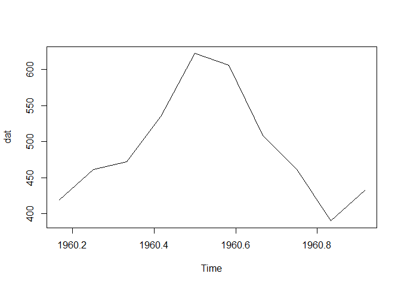

```r
    # Uso de ses() en el pronostico de una serie a h=20
    dat<-window(AirPassengers,start=c(1960,3))
    plot(dat)
```

```r
    # Creamos el pronostico al horizonte 3
    fc <- ses(dat, h =3)
    # Usamos summary() para ver los resultados
    head(summary(fc))
```

```
##
## Forecast method: Simple exponential smoothing
##
## Model Information:
## Simple exponential smoothing
##
## Call:
##  ses(y = dat, h = 3)
##
##   Smoothing parameters:
##     alpha = 0.9999
##
##   Initial states:
##     l = 418.996
##
##   sigma:  56.8325
##
##      AIC     AICc      BIC
## 109.8280 113.8280 110.7358
##
## Error measures:
##                    ME     RMSE      MAE       MPE     MAPE MASE      ACF1
## Training set 1.300111 56.83252 47.70159 -0.340655 9.726179  NaN 0.3659019
##
## Forecasts:
##          Point Forecast    Lo 80    Hi 80    Lo 95    Hi 95
## Jan 1961       431.9958 359.1620 504.8296 320.6061 543.3855
## Feb 1961       431.9958 328.9984 534.9932 274.4749 589.5167
## Mar 1961       431.9958 305.8524 558.1392 239.0761 624.9155
```

```
##          Point Forecast    Lo 80    Hi 80    Lo 95    Hi 95
## Jan 1961       431.9958 359.1620 504.8296 320.6061 543.3855
## Feb 1961       431.9958 328.9984 534.9932 274.4749 589.5167
## Mar 1961       431.9958 305.8524 558.1392 239.0761 624.9155
```

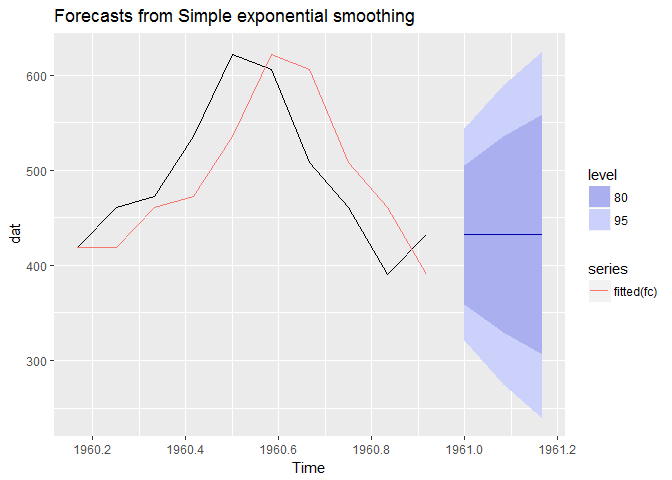

```r
    # Pintamos la serie con el pronostico y la serie ajustada
    autoplot(fc) + autolayer(fitted(fc))
```

Como vemos el modelo SES es bastante simple y los resultados difieren poco del modelo ingenuo (`naive()`).

## 7.5 Holt para tendendicas

El método de tendencia local de Holt se implementa en la función `holt()`, es aplicable a series con una clara tendencia, no es aplicable a series estacionales. La función tiene el parametro damped que sirve para aplicar un suavizado a la curva de pronostico.

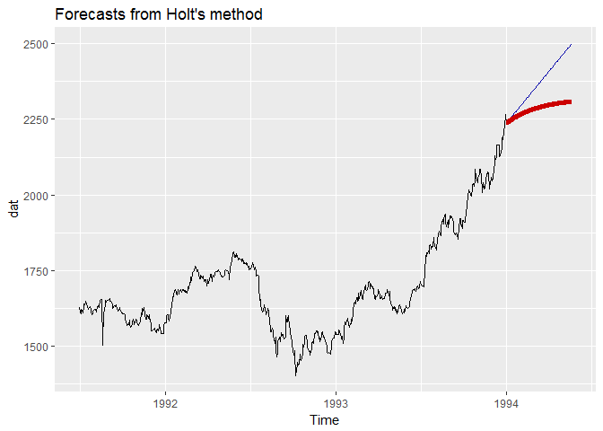

```r
    # Pronostico de hotl para la serie diaria de DAX en 1991-1994
    dat<-window(EuStockMarkets[,"DAX"], start=1991, end=1994)
    # str(dat)
    # plot(dat)

    #Realizamos un pronostico a 100 días por holt
    fc <- holt(dat  ,h=100) # esto para tendencias de pendiente constante

    # Pronostico con version con suavizado
    fc1 <- holt(dat,h=100, damped = TRUE)
    #summary(fc)
    autoplot(fc, PI=F) + autolayer(fc1, PI=F, lwd=2, col="red")
```

```r
    # probamos que los residuos sean ruido blanco
    checkresiduals(fc)
```

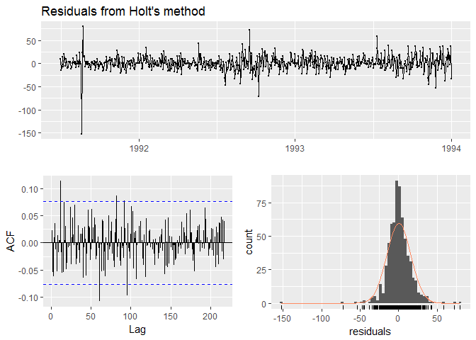

```
##
##  Ljung-Box test
##
## data:  Residuals from Holt's method
## Q* = 530.97, df = 516, p-value = 0.3148
##
## Model df: 4.   Total lags used: 520
```

## 7.6 Holt-Winters para datos estacionales

La función `hw()` produce pronósticos usando el método de Holt-Winters específico para cualquier serie estacional. Hay que especificar el método elegido de pronostico si aditivo multiplicativo. El primero añade ciclos iguales a los actuales y el segundo son ciclos ampliados.

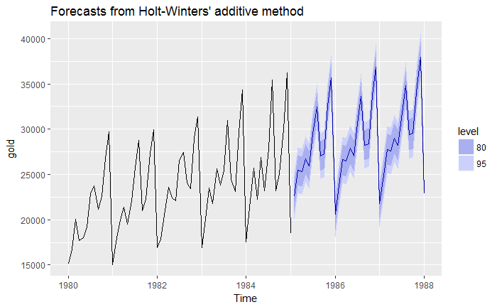

prediccion de oro con holtwinter

```r
    # Trabajaremos con la serie del oro de ejemplo
    # queremos un pronostico a 3 años
    fc <- hw(gold, seasonal = "additive", h =12*3)

    #fc1 <- hw(gold, seasonal = "multiplicative", h =12*3)
    autoplot(fc)
    #  autoplot(fc) + autolayer(fc1, PI=F, lwd=2, col="red")
    checkresiduals(fc)
```

[output not shown]

## 7.7 Predicción automática con `ets`

La función ETS (alisamiento exponencial), proporciona una forma completamente automática de realizar pronósticos para una amplia gama de series de temporales. La llamada de la funcion es algo diferente, pues `ets()` ajusa los parámetros del modelo, pero para realizar el pronóstico. Digamos que selecciona previamente qué modelo elegir que se ajuste mejor, y después lousaremos como un función más a través de la llamada a `forecast()`.

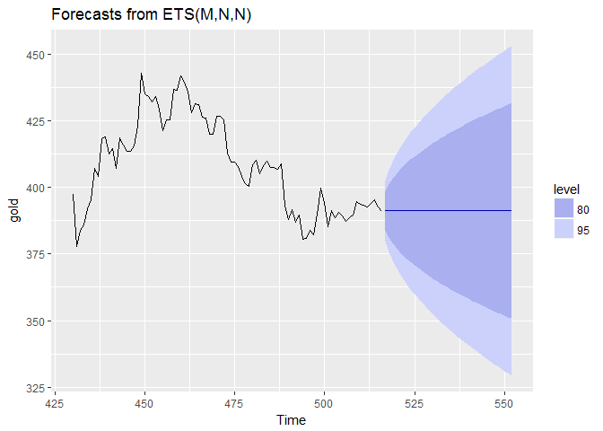

```r
    # Calculamos un pronóstico automático con ETS
    fc <- forecast(ets(gold),h=3*12)
    # Pintamos los datos  del pronóstico
    autoplot(fc)
```

```r
    # Análisis de residuos
    #checkresiduals(fc)
```

```r
    # CReamos una función para almacenar los resultados de
    # pronosticos ETS
    p_ets <- function(y, h) {
      forecast(ets(y), h = h)
    }

    # aplicamos la validación cruzada tsCV() a los métodos para horizonte de 6 meses
    e1 <- tsCV(gold, forecastfunction = p_ets, h = 6)
    e2 <- tsCV(gold, forecastfunction = snaive, h = 6)

    # calculamos el MSE de cada resultado)
    mean(e1^2, na.rm = TRUE)
    mean(e2^2, na.rm = TRUE)
```

[output not shown]

Como vemos el pronostico de `ets()` no siempre es bueno, incluso en series cíclicas no estacionales funciona bastante mal como por ejemplo con la serie *lynx* que contiene el número de trampas de lince entre 1821-1934.

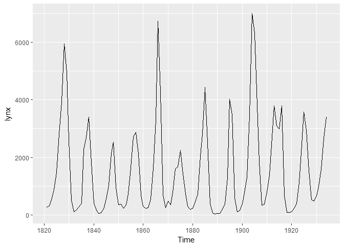

```r
    # Pintamos la serie lynx{datasets}
    require(ggplot2)
    autoplot(lynx)
```

```r
    # Ajustamos un modelo ets a la serie
    fit <- ets(lynx)

    # veos los parametros del calculo
    summary(fit)
```

```
## ETS(M,N,N)
##
## Call:
##  ets(y = lynx)
##
##   Smoothing parameters:
##     alpha = 0.9999
##
##   Initial states:
##     l = 169.2223
##
##   sigma:  0.9489
##
##      AIC     AICc      BIC
## 2052.369 2052.587 2060.578
##
## Training set error measures:
##                    ME     RMSE      MAE       MPE     MAPE      MASE
## Training set 28.30726 1182.181 824.4878 -44.94341 94.83425 0.9923325
##                   ACF1
## Training set 0.3785704
```

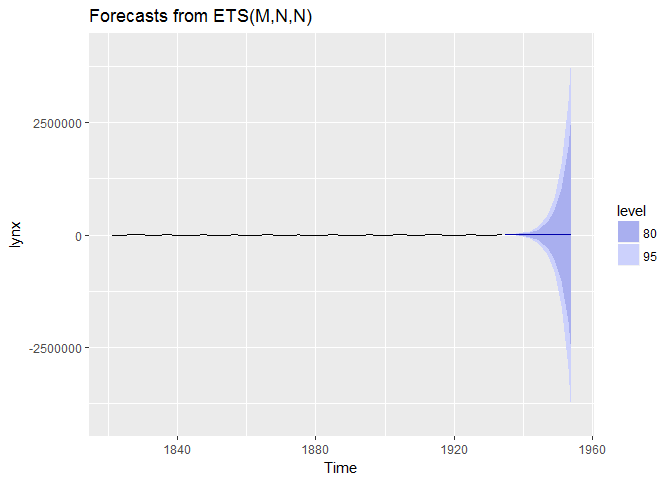

```r
    # Pintamos un pronostico a 20 años
    fit %>% forecast(h=20) %>% autoplot()
```

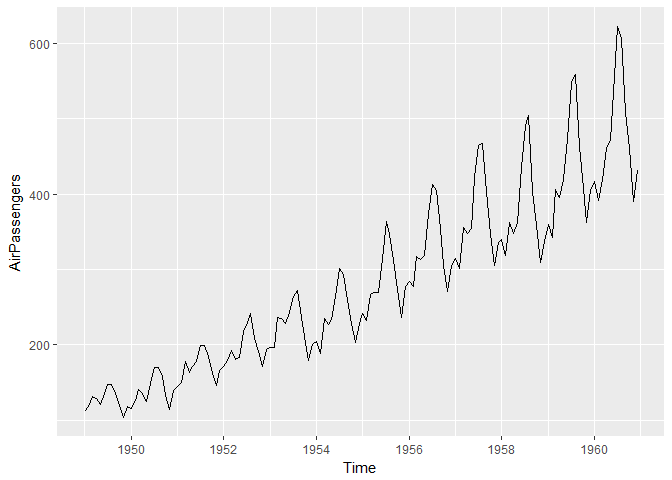

```r
    # sin embargo con series estacionales si va bien
    autoplot(AirPassengers)
```

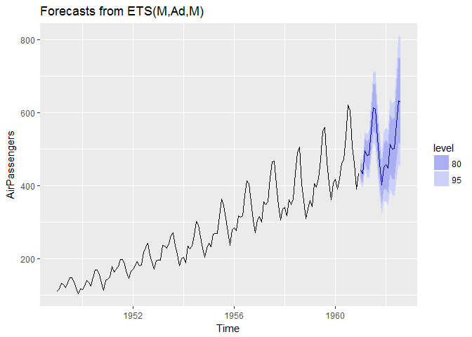

```r
    fit <- ets(AirPassengers)
    fit %>% forecast(h=20) %>% autoplot()
```

# 8 TRANSFORMACIONES y DESCOMPOSICIÓN DE SERIES TEMPORALES

El propósito de la transformación de series temporales es simplificar los patrones en los datos y quitar las fuentes de variación evidentes. Se trata en definitiva, de poder aplicar los métodos de pronóstico estadístico y por tanto de obtener con la transformación una serie estacionaria sobre la que trabajar mejor.

Las transformaciónes de las series temporales extraen la esencia de los datos, y permiten analizar los componentes de tendencia, ciclo y variabilidad de forma independiente y mejorar la predicción.

La descomposición es la separación en componentes de una serie temporal,buscando tambien la simplificación del analisis en grupos sencillos. La principal descomposición que realizamos es extraer de la serie original las componentes de tendencia, ciclo y remanente o parte que no se puede explicar.

## 8.1 Diferenciación

La diferrenciación de una serie consiste en tranformar la original en otra con las diferencias o incrementos en cada x pasos. Es decir, la resta de dos valores consecutivos de la serie. Con esto conseguimos en muchos casos **eliminar la tendencia de la serie** y obtener una variable estacionaria. La diferenciación elimina patrones sistemáticos como tendencia y estacionalidad de los datos.

La función `diff()` aplicada sobre una serie temporal nos devuelve la serie diferenciada. Como veremos en el siguiente ejemplo en la serie diferenciada la gráfic de acf cae inmediatamente a valores próximos a cero, lo que indica que se trata de una serie estacionaria. Por contra las series no estacionarias tienen valores altos y positivos como la serie original.

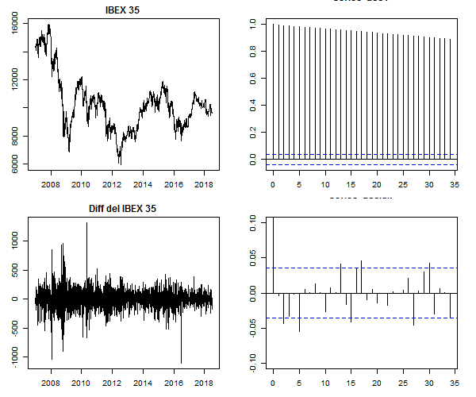

Diferenciación de la serie daria del IBEX y autocorrelación

```r
    require(quantmod)
    require(ggplot2)
    # leemos los ultimos 10 años del ibex en diarios
    acc1 <- getSymbols("^IBEX",
                       src ="yahoo",
                       periodicity = "daily",# "monthly",
                       warning= "FALSE",
                       adjust = TRUE,
                       auto.assign=FALSE)

    acc.dif<-diff(Cl(acc1))
    #length(acc.dif)
    acc.dif<-na.omit(acc.dif)
    acc1<-na.omit(Cl(acc1))
    png('imagenes/grafibex.png',height = 500, width = 600, units = "px")
        par(mfrow=c(2,2),mar=c(3,3,2,2))
        #spectrum(acc.dif)
        plot.zoo(acc1,main="IBEX 35")
        acf(acc1)
        plot.zoo(acc.dif,main="Diff del IBEX 35")
        acf(acc.dif, ylim=c(-0.1,0.1))
    dev.off()

    Box.test(acc.dif, lag=10, type="Ljung-Box")
```

[output not shown]

Cuando la diferenciación de un retardo no proporciona una serie estacionaria, puede probarse la segunda derivada - `diff(diff(serie))`- o también la diferenciación por retardos diferentes por ejemplo para desestacionalizar una serie. Si el ciclo es anual, puede hacerse `diff(serie, lag=12)` por ejemplo.

Para saber qué intervalo es el adecuado para diferenciar existen algunos test como el `kpss`.

```r
    library(urca)
    acc1 %>% ur.kpss() %>% summary()

    # Calculo del lag apropiado
    ndiffs(acc1)
```

```r
#######################
# KPSS Unit Root Test #
#######################

Test is of type: mu with 9 lags.

Value of test-statistic is: 8.4046

Critical value for a significance level of:
                10pct  5pct 2.5pct  1pct
critical values 0.347 0.463  0.574 0.739
```

El valor del test para la serie original de 8.4046 es muy alto indicando que habría que diferenciar la serie. PAra ver que valor de retardo lag de diferencia es apropiado podemos usar la función `ndiffs(serie)`.

## 8.2 Transformaciones de Box-Cox

La transformación de Box-Cox se usa para estabilizar la *varianza* de la serie, esto es, para que las variaciones sean comparables en escala a lo largo del tiempo. Se aplica por tanto en series estacionales o con ciclos. La función `BoxCox()` tiene dos argumentos principales, la serie origen y `lambda`. El calculo de lambda que hace a la serie menos variable puede hacerse de forma automática con la función `BoxCox.lambda(serie)`.

Por ejemplo, en la serie `AirPassengers` vemos ciclos estacionales que además crecen con el tiempo, para estabilizar la varianza aplicamos al ejemplo una transformación Box COx con lambda=-0.2947156, calculado automáticamente por la función BoxCox.lambda. Como vemos en las gráficas los ciclo resultantes son más iguales.

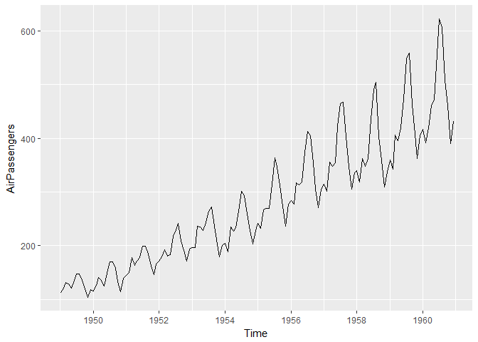

```r
    # Serie de num de pasajeros
    autoplot(AirPassengers)
```

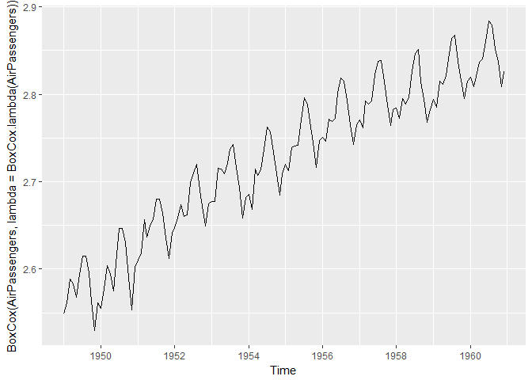

```r
    # Cálculo de lambda=BoxCox.lambda(AirPassengers)
    autoplot(BoxCox(AirPassengers,lambda=BoxCox.lambda(AirPassengers)))
```

## 8.3 Logaritmo

Una de las transformaciones clasicas de la series con comportamientos exponenciales o de gran variabilidad es el logaritmo. Haciendo un log de la serie conseguimos cambiar las tendencias exponenciales a lineales y las variaciones e vuelven más uniformes por lo que podemos trabajar con las series de manera habitual.

Vamos a ver los resultados para una serie como el precio del Bitcoin con eneorme variación de escala

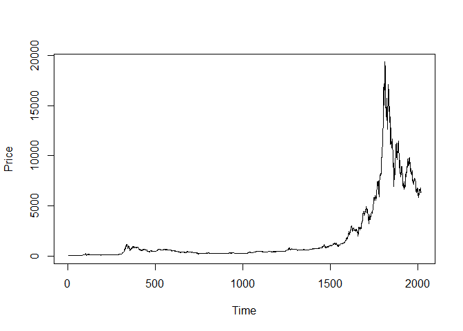

```r
    # Intalamos el paquete

    library(coindeskr) #R-Package connecting to Coindesk API

    # obtenemos los precios historicos del cambio BTC EUR
    pBTC<-get_historic_price(currency = "USD", start = "2013-01-01" ,end = Sys.Date() )
    plot.ts(pBTC)
```

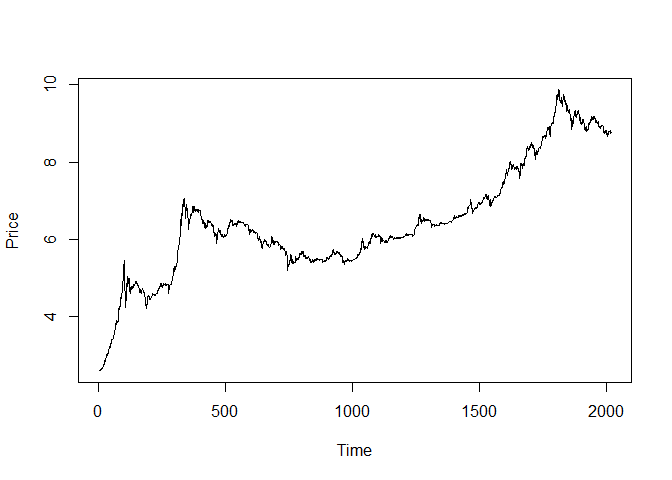

```r
    plot.ts(log(pBTC))
```

Vamos a ver un ejemlo:

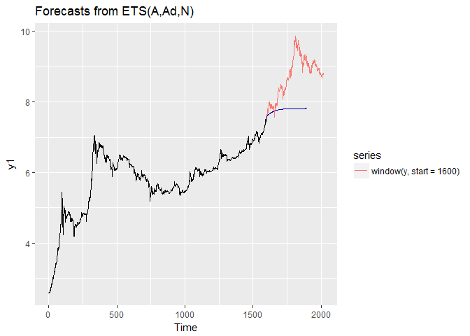

```r
    y<-ts(na.omit(log(pBTC)))
    y1<- window(y, end =1600)

    autoplot(forecast(ets(y1),300), PI=F) + autolayer(window(y, start=1600))
```

## 8.4 Descomposición de series

### 8.4.1 `decompose`

Es un método clásico para series con estacionalidad. Se puede aplicar con dos tipos, el aditivo y el multiplicativo, uno suma y otro divide la estacionalidad en proporción al valor observado de tendencia. El resultado de aplicar las funiones de descomposición de series `decompose()` es una terna de series formado por el componente de tendencia, el de ciclo y el que resta que podemos decir es el aleatorio.

Veamos un ejemplo:

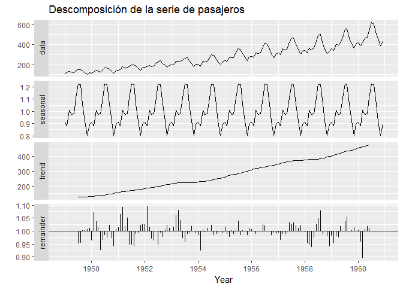

```r
AirPassengers %>% decompose(type="multiplicative") %>%
  autoplot() + xlab("Year") +
  ggtitle("Descomposición de la serie de pasajeros")
```

### 8.4.2 `seasonal`

Otro método de descomposición de series es el `X11` que en R está programado dentro del paquete `seasonal`. Tienen parecidas características, pero aporta algunos gráficos interesantes que vamos a mostrar. Una de las novedades es que el componente estacional no es constante.

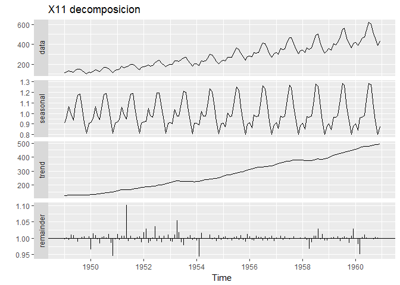

```r
    require(seasonal)
    AirPassengers %>% seas(x11="") -> fit

    autoplot(fit) +
  ggtitle("X11 decomposicion")
```

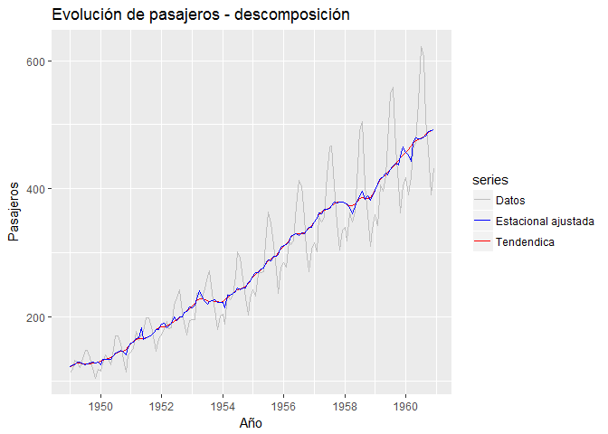

```r
    autoplot(AirPassengers, series="Datos") +
        autolayer(trendcycle(fit), series="Tendendica")    +
        autolayer(seasadj(fit), series="Estacional ajustada")    +
        xlab("Año") + ylab("Pasajeros") +
        ggtitle("Evolución de pasajeros - descomposición") +
        scale_colour_manual(values=c("gray","blue","red"),
             breaks=c("Datos","Estacional ajustada","Tendendica"))
```

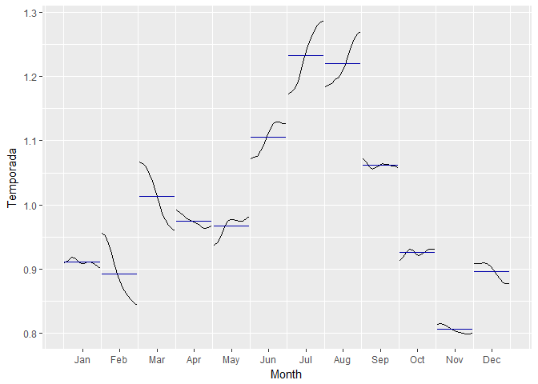

```r
    # otro grafico interesante
    fit %>% seasonal() %>% ggsubseriesplot() + ylab("Temporada")
```

El paquete `seasonal` da acceso a las series descompuestas con las funciones `seasadj()`, `trendcycle()` and `remainder()` (estacional, tendencia y resto).

### 8.4.3 `stl`

Como última alterntiva veremos la funcion `stl()` que también realiza la descomposción de una serie estacional, con la ventaja de que no solo es válido como las anteriores para series de ciclos mensuales, anuales o semanales, es una formulación más aséptica, y válida para cualquier frecuencia.

Además permite que el componente estacional varíe en el tiempo, no como `decompose`, y es más robusto frente a outliers o valores fuera de rango, pero hay que tener cuidado con estas funciones, pues no tienen ajuste automatico a calendarios y por tanto en series con secuencias discontinuas como datos diarios de bolsa (donde faltan los fines de semana y festivos) hay -previamente- que hacer alguna transformación temporal.

Los parámetros de la función son:

- *t.window* que controla la tendencia (indica el lag que se toma en consideración para la tendencia)
- *s.window* que controla el ciclo. (si se pone =“periodic” lo calcula automáticamente)

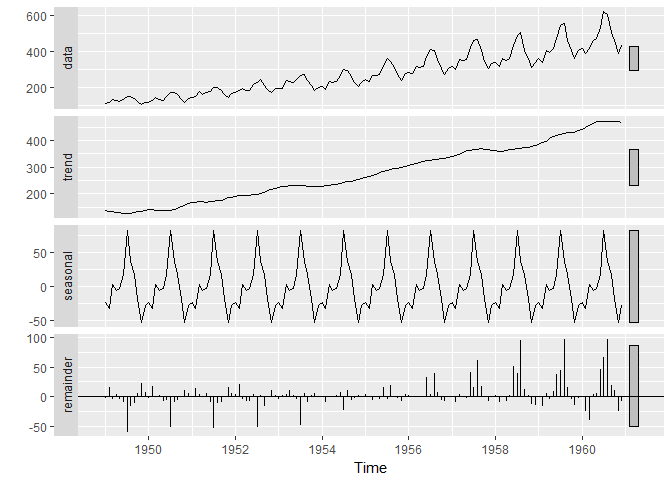

```r
AirPassengers %>%
  stl(t.window=12, s.window="periodic", robust=TRUE) %>%
  autoplot()
```

## 8.5 Pronosticos sobre descomposiciones de series

Una vez hemos realizado una descomposición de la serie que creemos adecuada, pordemos realizar pronosticos sobre los datos, y modular estos según cada componente de la descomposición. Esto es, podemos ejecutar un pronostico de tendencia sobre la parte de tendencia de la descomposición, y aplicarle luego la modulación que aporta la arte de estacionalidad.

[figure not shown]

autoplot(smodel)

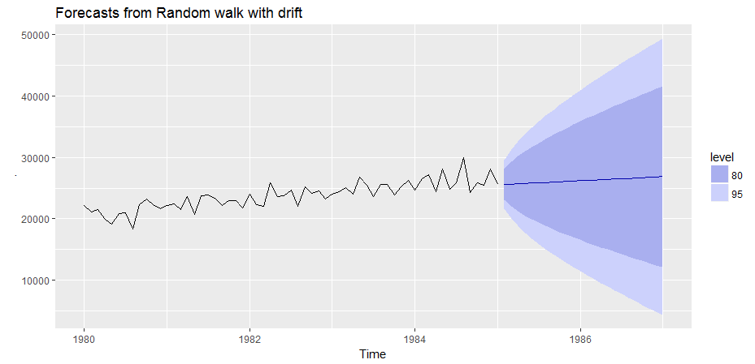

smodel %>% seasadj() %>% rwf(24,drift=TRUE) %>% autoplot()

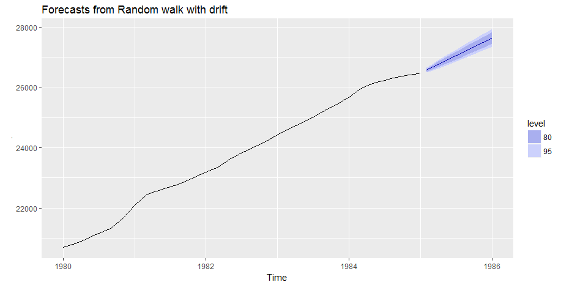

smodel %>% trendcycle() %>% rwf(12,drift=TRUE)

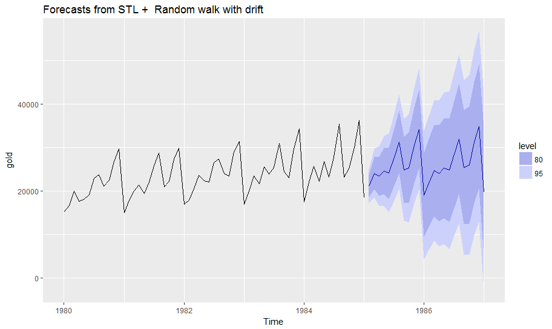

stl modelo

[figure not shown]

pronosico con ets modelo

```r
    # creamos una descomposición de la serie gold
    smodel<- stl(gold, s.window="periodic")
    autoplot(smodel)
    # Creamos un pronostico con el metodo drif de la parte de estacionalidad ajustada de la serie descompuesta
    smodel %>% seasadj() %>%  rwf(24,drift=TRUE)  %>% autoplot()

    # Idem pronostico con el metodo drif de la parte de tendencia de la descomposición
    # para 12 meses
    smodel %>% trendcycle() %>%  rwf(12,drift=TRUE)  %>% autoplot()

    # lo mismo usandola función forecast
    smodel %>% forecast(method="rwdrift") %>% autoplot()
    # lo mismo usando la función stlf en la que hay que indicar el método de pronostico
    autoplot(stlf(gold, method='rwdrift'))

    #Podemos usar un modelo ets
    smodel<- ets(gold)
    smodel %>% forecast() %>% autoplot()
```